# kkkkk

```
[-1, 1] aralığındaki olasılık: 0.0
```

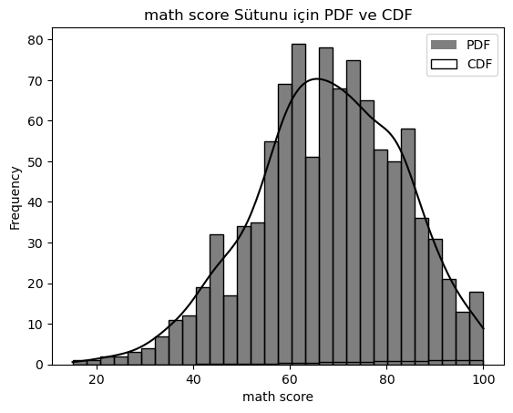

```python
# CSV dosyasını Pandas DataFrame'e yükleme
veri = pd.read_csv('exams.csv')  # 'veri.csv' dosyasının adını ve yolunu uygun şekilde belirtin

# Örnek olarak 'sutun_adı' adlı bir sütunu seçin
secilen_sutun = 'math score'  # İlgili sütun adını gerçek bir sütun adıyla değiştirin
pdf = veri[secilen_sutun].plot(kind='hist', bins=30,color='black', density=True, alpha=0.5, label='PDF')
cdf = veri[secilen_sutun].plot(kind='hist', bins=30, density=True, cumulative=True, histtype='step', color='black', label='CDF')

# Grafiklerin görünürlüğü ve başlığı
plt.legend()
plt.title(f'{secilen_sutun} Sütunu için PDF ve CDF')

# Belirli bir veri aralığı için olasılık hesaplama
alt_sınır = -1  # Belirli bir alt sınır
ust_sınır = 1   # Belirli bir üst sınır

olasilik = len(veri[(veri[secilen_sutun] >= alt_sınır) & (veri[secilen_sutun] <= ust_sınır)]) / len(veri)
print(f'[{alt_sınır}, {ust_sınır}] aralığındaki olasılık: {olasilik}')


# Seaborn ile distplot kullanarak örnek bir görselleştirme
sns.histplot(veri[secilen_sutun] , color='black',kde=True, bins=30)
```

Grafiği incelediğinizde, "math score" sütununda bulunan puanların dağılımını görürsünüz. Histogram, belirli puan aralıklarındaki sıklığı gösterir. Yoğunluk eğrisi (KDE), dağılımın sürekli bir fonksiyonunu temsil eder ve bu fonksiyon, veri noktalarının yoğunlukları hakkında bir tahminde bulunur. Bu şekilde, puan dağılımının genel formunu ve odaklanılması gereken bölgeleri görebilirsiniz.

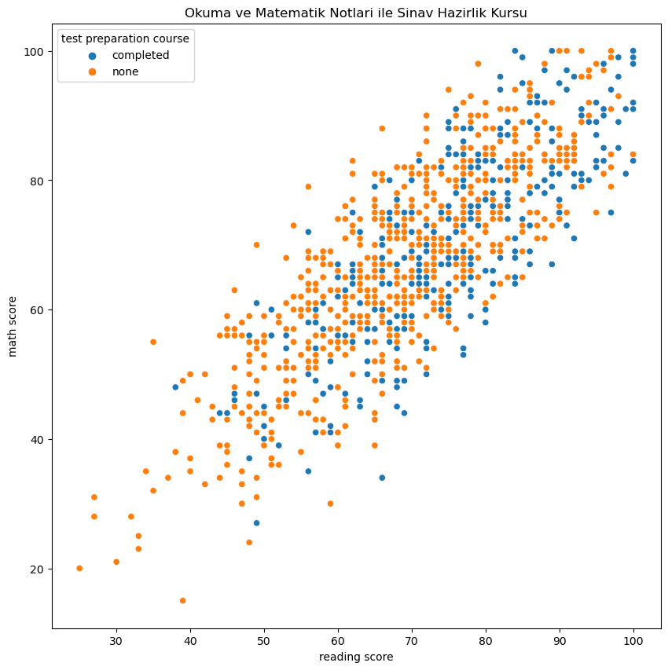

```python
veri = pd.read_csv('exams.csv')
f, ax = plt.subplots(figsize=(10, 10))
sns.scatterplot(x="reading score", y="math score",data=veri,hue="test preparation course",ax=ax)
plt.title('Okuma ve Matematik Notlari ile Sinav Hazirlik Kursu')
```

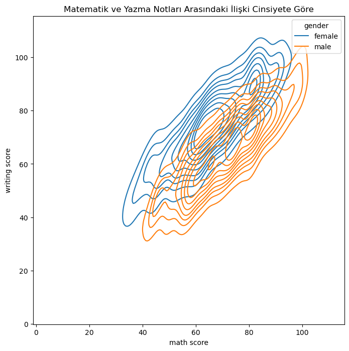

```python
ff, ax = plt.subplots(figsize=(8, 8))
ax.set_aspect("equal")

# Draw a contour plot to represent each bivariate density
sns.kdeplot(
    data=df,
    x="math score",
    y="writing score",
    hue="gender",
    thresh=.1,
)
plt.title('Matematik ve Yazma Notları Arasındaki İlişki Cinsiyete Göre')
```

Bu kdeplot (Kernel Density Estimation plot) grafiği, "math score" (matematik notu) ile "writing score" (yazma notu) arasındaki ilişkiyi görselleştirmek amacıyla kullanılmış gibi görünüyor. KDE, iki değişkenin olasılık yoğunluk fonksiyonlarını (probability density functions) temsil eden bir grafik türüdür. Bu grafik, öğrencilerin matematik notları ile yazma notları arasındaki ilişkiyi göstermektedir. X ekseni matematik notlarını, y ekseni ise yazma notlarını temsil eder. Renkler aracılığıyla cinsiyet grupları ayırt edilmiştir. Her bir renk altında, cinsiyet gruplarına ait öğrencilerin matematik ve yazma notları arasındaki dağılımları gözlemlenebilir.

Grafikteki eğrilerin yoğunluğu, belirli bir not kombinasyonunun ne kadar sık görüldüğünü gösterir. Örneğin, matematik notları yüksek olan öğrencilerin genellikle yazma notlarının da yüksek olduğu durumlar mı var, yoksa bu iki not arasında belirgin bir desen görmek mümkün mü, bunlar görselleştirme ile anlaşılabilir.

Bu grafik, matematik ve yazma notları arasındaki genel ilişkinin yanı sıra, cinsiyet grupları arasındaki potansiyel farklılıkları da keşfetmek için kullanışlı bir araçtır.

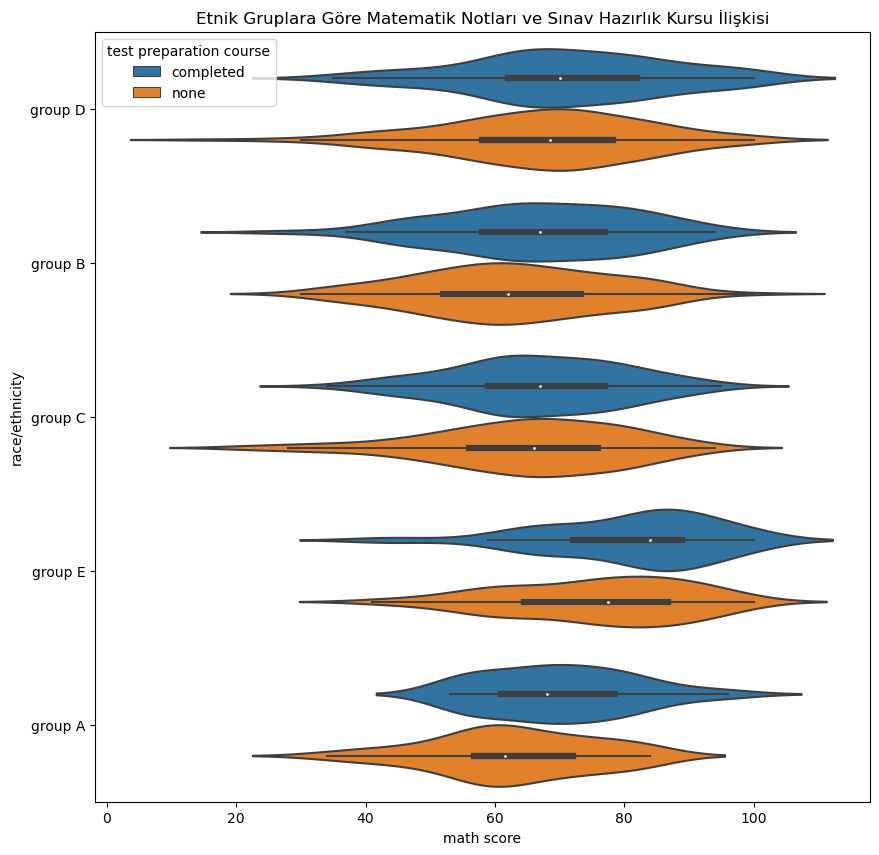

```python
f, ax = plt.subplots(figsize=(10, 10))
sns.violinplot(data=df, x="math score", y="race/ethnicity", hue="test preparation course", orient="h", fill=False,ax=ax)
plt.title('Etnik Gruplara Göre Matematik Notları ve Sınav Hazırlık Kursu İlişkisi')
```

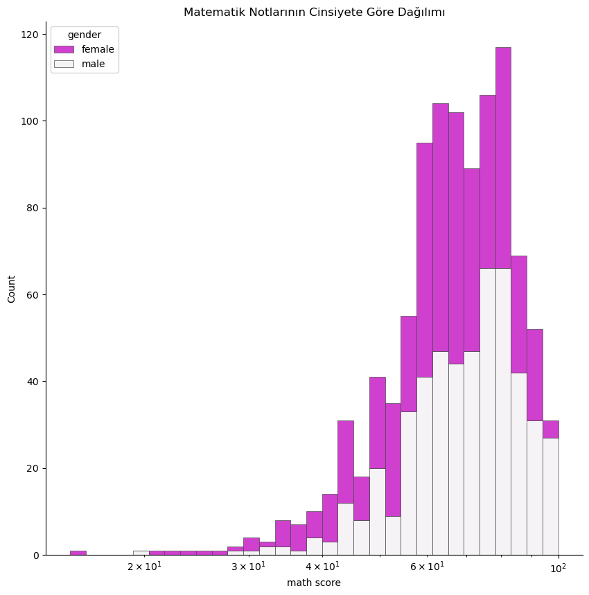

```python
f, ax = plt.subplots(figsize=(10,10))
sns.despine(f)

sns.histplot(
    data=df,
    x="math score", hue="gender",
    multiple="stack",
    palette="light:m_r",
    edgecolor=".3",
    linewidth=.5,
    log_scale=True,
)
plt.title('Matematik Notlarının Cinsiyete Göre Dağılımı')
```

histplot kullanarak matematik notlarının cinsiyete göre dağılımını görselleştirmektedir. Bu grafik, cinsiyet temelindeki öğrenci matematik notlarının dağılımını gösterir. Renkler aracılığıyla cinsiyet grupları ayrılmıştır, böylece her bir cinsiyetin not dağılımını görmek daha kolaydır. Çubuk yükseklikleri, belirli bir not aralığındaki öğrenci sayısını temsil eder ve bu dağılım, cinsiyetler arasındaki farkları anlamamıza yardımcı olabilir.